# Assigment 9.2 Clustering

Larry Heckel

May 11, 2019

# Assignment 9.2 Instructions

Labeled data is not always available. For these types of datasets, you can use unsupervised algorithms to extract structure. The k-means clustering algorithm and the k nearest neighbor algorithm both use the Euclidean distance between points to group data points. The difference is the k-means clustering algorithm does not use labeled data.

In this problem, you will use the k-means clustering algorithm to look for patterns in an unlabeled dataset. The dataset for this problem is found at data/clustering-data.csv.

1. Plot the dataset using a scatter plot.
2. Fit the dataset using the k-means algorithm from k=2 to k=12. Create a scatter plot of the resultant clusters for each value of k.
3. As k-means is an unsupervised algorithm, you cannot compute the accuracy as there are no correct values to compare the output to. Instead, you will use the average distance from the center of each cluster as a measure of how well the model fits the data. To calculate this metric, simply compute the distance of each data point to the center of the cluster it is assigned to and take the average value of all of those distances.

   Calculate this average distance from the center of each cluster for each value of k and plot it as a line chart where k is the x-axis and the average distance is the y-axis.
4. One way of determining the “right” number of clusters is to look at the graph of k versus average distance and finding the “elbow point”. Looking at the graph you generated in the previous example, what is the elbow point for this dataset?

```r
# libraries to use
library(ggplot2)
# library(readxl)
# library(DataExplorer)
# library(ggm)
library(readr)
# library(dplyr)
# # library(stringr)
# # library(psych)
# # library(janitor)
# library(car)
# library(QuantPsyc)
# # library(pastecs)
# # library(sqldf)
#library(caret)
#library(class)
library(factoextra)
library(purrr)

options(scipen=100)
options(digits=5)

# read the data files
clusterData <- read_csv("clustering-data.csv")
set.seed(1206)
```

##Plot the dataset using a scatter plot.

[figure not shown]

##Fit the dataset using the k-means algorithm from k=2 to k=12. Create a scatter plot of the resultant clusters for each value of k.

### Cluster k=2

```r
k2 <- kmeans(clusterData, centers=2, nstart=25)
str(k2)
```

```
## List of 9
##  $ cluster     : int [1:4022] 2 2 1 1 1 1 1 1 2 2 ...
##  $ centers     : num [1:2, 1:2] 207.8 62.3 203.3 162.4
##   ..- attr(*, "dimnames")=List of 2
##   .. ..$ : chr [1:2] "1" "2"
##   .. ..$ : chr [1:2] "x" "y"
##  $ totss       : num 28608985
##  $ withinss    : num [1:2] 3057964 5385717
##  $ tot.withinss: num 8443681
##  $ betweenss   : num 20165304
##  $ size        : int [1:2] 1308 2714
##  $ iter        : int 1
##  $ ifault      : int 0
##  - attr(*, "class")= chr "kmeans"
```

```r
k2
```

```
## K-means clustering with 2 clusters of sizes 1308, 2714
##
## Cluster means:
##         x      y
## 1 207.800 203.29
## 2  62.282 162.41
##
## Clustering vector:
##    [1] 2 2 1 1 1 1 1 1 2 2 2 2 2 2 2 2 2 2 2 2 2 2 2 2 2 2 2 2 2 2 2 1 1 1
##   [35] 1 1 1 1 1 1 1 1 1 1 1 1 1 1 1 1 1 1 1 1 1 1 1 1 1 1 1 1 1 1 1 1 1 1
##   [69] 1 1 1 1 1 1 1 1 1 1 1 1 1 1 1 1 1 1 1 1 1 1 1 1 1 1 1 1 1 1 1 1 1 1
##  [103] 1 1 1 1 1 1 1 1 1 1 1 1 1 1 1 1 1 1 1 1 1 1 1 1 1 1 1 1 1 2 1 1 1 1
##  [137] 1 1 1 1 1 1 1 1 1 1 1 1 1 1 1 1 1 1 1 1 1 1 1 1 1 1 1 1 1 1 1 1 1 1
##  [171] 1 1 1 1 1 1 1 1 1 1 1 1 1 1 1 1 1 1 1 1 1 1 2 2 2 2 2 2 2 2 2 2 2 2
##  [205] 2 2 2 2 2 2 2 2 2 2 2 1 1 1 1 1 1 1 1 1 1 1 1 1 1 1 1 1 1 1 1 1 1 1
```

[output cut: 122 more lines]

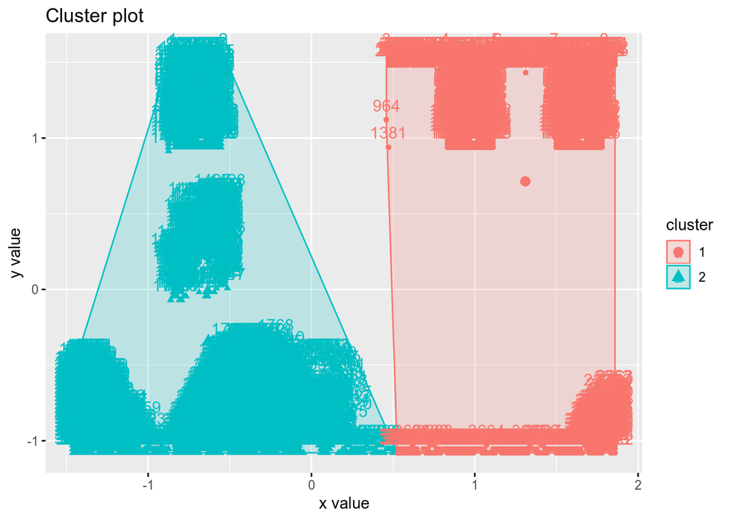

```r
k2_graph <- fviz_cluster(k2, clusterData)
k2_graph
```

### Cluster k=3

```r
k3 <- kmeans(clusterData, centers=3, nstart=25)
str(k3)
```

```
## List of 9
##  $ cluster     : int [1:4022] 1 1 3 3 3 3 3 3 1 1 ...
##  $ centers     : num [1:3, 1:2] 38.7 87.3 209.2 180.5 144.4 ...
##   ..- attr(*, "dimnames")=List of 2
##   .. ..$ : chr [1:3] "1" "2" "3"
##   .. ..$ : chr [1:2] "x" "y"
##  $ totss       : num 28608985
##  $ withinss    : num [1:3] 2400602 815599 2798177
##  $ tot.withinss: num 6014378
##  $ betweenss   : num 22594607
##  $ size        : int [1:3] 1347 1402 1273
##  $ iter        : int 2
##  $ ifault      : int 0
##  - attr(*, "class")= chr "kmeans"
```

```r
k3
```

```
## K-means clustering with 3 clusters of sizes 1347, 1402, 1273
##
## Cluster means:
##         x      y
## 1  38.733 180.46
## 2  87.299 144.37
## 3 209.166 205.18
##
## Clustering vector:
##    [1] 1 1 3 3 3 3 3 3 1 1 1 1 1 1 1 1 1 1 1 1 1 1 1 1 1 1 1 1 1 1 1 3 3 3
##   [35] 3 3 3 3 3 3 3 3 3 3 3 3 3 3 3 3 3 3 3 3 3 3 3 3 3 3 3 3 3 3 3 3 3 3
##   [69] 3 3 3 3 3 3 3 3 3 3 3 3 3 3 3 3 3 3 3 3 3 3 3 3 3 3 3 3 3 3 3 3 3 3
##  [103] 3 3 3 3 3 3 3 3 3 3 3 3 3 3 3 3 3 3 3 3 3 3 3 3 3 3 3 3 3 1 3 3 3 3
##  [137] 3 3 3 3 3 3 3 3 3 3 3 3 3 3 3 3 3 3 3 3 3 3 3 3 3 3 3 3 3 3 3 3 3 3
##  [171] 3 3 3 3 3 3 3 3 3 3 3 3 3 3 3 3 3 3 3 3 3 3 1 1 1 1 1 1 1 1 1 1 1 1
```

[output cut: 123 more lines]

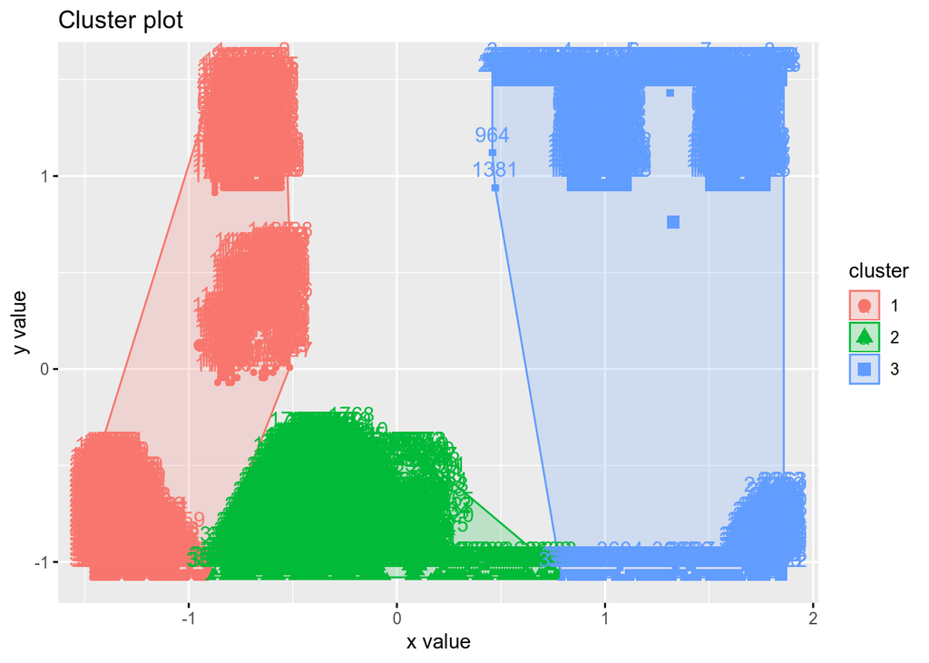

```r
k3_graph <- fviz_cluster(k3, clusterData)
k3_graph
```

### Cluster k=4

```r
k4 <- kmeans(clusterData, centers=4, nstart=25)
str(k4)
```

```
## List of 9
##  $ cluster     : int [1:4022] 3 3 1 1 1 1 1 1 3 3 ...
##  $ centers     : num [1:4, 1:2] 209.2 88.1 57.4 14.5 205.2 ...
##   ..- attr(*, "dimnames")=List of 2
##   .. ..$ : chr [1:4] "1" "2" "3" "4"
##   .. ..$ : chr [1:2] "x" "y"
##  $ totss       : num 28608985
##  $ withinss    : num [1:4] 2791492 778264 334025 105897
##  $ tot.withinss: num 4009678
##  $ betweenss   : num 24599306
##  $ size        : int [1:4] 1272 1376 782 592
##  $ iter        : int 2
##  $ ifault      : int 0
##  - attr(*, "class")= chr "kmeans"
```

```r
k4
```

```
## K-means clustering with 4 clusters of sizes 1272, 1376, 782, 592
##
## Cluster means:
##         x      y
## 1 209.197 205.24
## 2  88.122 144.53
## 3  57.427 207.30
## 4  14.480 142.97
##
## Clustering vector:
##    [1] 3 3 1 1 1 1 1 1 3 3 3 3 3 3 3 3 3 3 3 3 3 3 3 3 3 3 3 3 3 3 3 1 1 1
##   [35] 1 1 1 1 1 1 1 1 1 1 1 1 1 1 1 1 1 1 1 1 1 1 1 1 1 1 1 1 1 1 1 1 1 1
##   [69] 1 1 1 1 1 1 1 1 1 1 1 1 1 1 1 1 1 1 1 1 1 1 1 1 1 1 1 1 1 1 1 1 1 1
##  [103] 1 1 1 1 1 1 1 1 1 1 1 1 1 1 1 1 1 1 1 1 1 1 1 1 1 1 1 1 1 3 1 1 1 1
##  [137] 1 1 1 1 1 1 1 1 1 1 1 1 1 1 1 1 1 1 1 1 1 1 1 1 1 1 1 1 1 1 1 1 1 1
```

[output cut: 124 more lines]

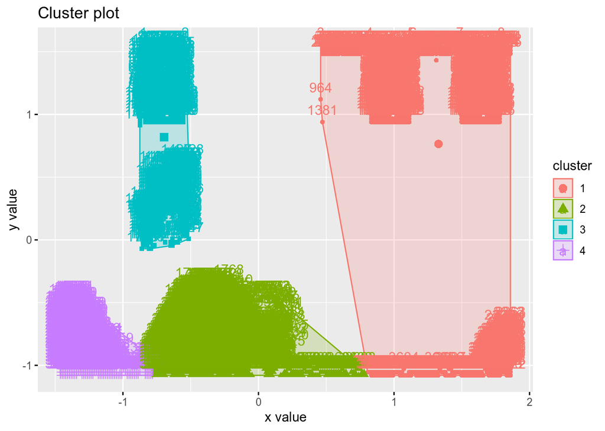

```r
k4_graph <- fviz_cluster(k4, clusterData)
k4_graph
```

### Cluster k=5

```r
k5 <- kmeans(clusterData, centers=5, nstart=25)
str(k5)
```

```
## List of 9
##  $ cluster     : int [1:4022] 1 1 4 4 4 4 4 4 1 1 ...
##  $ centers     : num [1:5, 1:2] 57.4 86.6 221.6 204 14.1 ...
##   ..- attr(*, "dimnames")=List of 2
##   .. ..$ : chr [1:5] "1" "2" "3" "4" ...
##   .. ..$ : chr [1:2] "x" "y"
##  $ totss       : num 28608985
##  $ withinss    : num [1:5] 334025 641125 267545 831376 97542
##  $ tot.withinss: num 2171613
##  $ betweenss   : num 26437372
##  $ size        : int [1:5] 782 1356 313 985 586
##  $ iter        : int 2
##  $ ifault      : int 0
##  - attr(*, "class")= chr "kmeans"
```

```r
k5
```

```
## K-means clustering with 5 clusters of sizes 782, 1356, 313, 985, 586
##
## Cluster means:
##         x      y
## 1  57.427 207.30
## 2  86.555 144.69
## 3 221.620 137.67
## 4 203.986 224.84
## 5  14.106 143.03
##
## Clustering vector:
##    [1] 1 1 4 4 4 4 4 4 1 1 1 1 1 1 1 1 1 1 1 1 1 1 1 1 1 1 1 1 1 1 1 4 4 4
##   [35] 4 4 4 4 4 4 4 4 4 4 4 4 4 4 4 4 4 4 4 4 4 4 4 4 4 4 4 4 4 4 4 4 4 4
##   [69] 4 4 4 4 4 4 4 4 4 4 4 4 4 4 4 4 4 4 4 4 4 4 4 4 4 4 4 4 4 4 4 4 4 4
##  [103] 4 4 4 4 4 4 4 4 4 4 4 4 4 4 4 4 4 4 4 4 4 4 4 4 4 4 4 4 4 1 4 4 4 4
```

[output cut: 125 more lines]

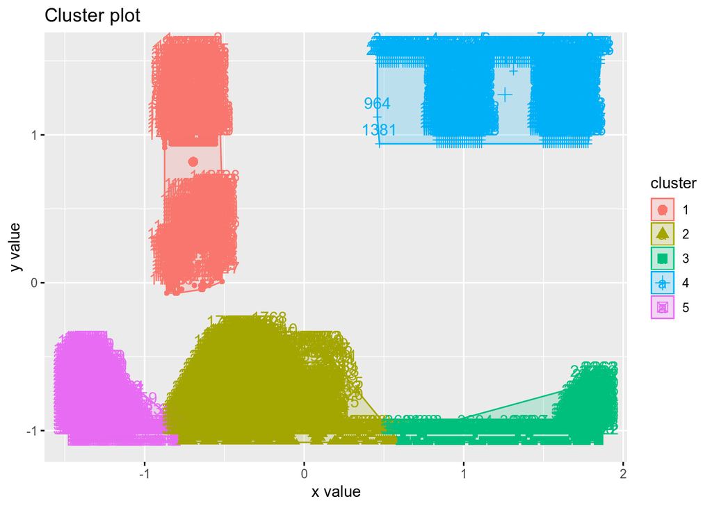

```r
k5_graph <- fviz_cluster(k5, clusterData)
k5_graph
```

### Cluster k=6

```r
k6 <- kmeans(clusterData, centers=6, nstart=25)
str(k6)
```

```
## List of 9
##  $ cluster     : int [1:4022] 6 6 2 2 2 2 4 4 6 6 ...
##  $ centers     : num [1:6, 1:2] 221.6 179.6 14.1 231.1 86.6 ...
##   ..- attr(*, "dimnames")=List of 2
##   .. ..$ : chr [1:6] "1" "2" "3" "4" ...
##   .. ..$ : chr [1:2] "x" "y"
##  $ totss       : num 28608985
##  $ withinss    : num [1:6] 267545 112959 97542 65847 641125 ...
##  $ tot.withinss: num 1519043
##  $ betweenss   : num 27089941
##  $ size        : int [1:6] 313 518 586 467 1356 782
##  $ iter        : int 3
##  $ ifault      : int 0
##  - attr(*, "class")= chr "kmeans"
```

```r
k6
```

```
## K-means clustering with 6 clusters of sizes 313, 518, 586, 467, 1356, 782
##
## Cluster means:
##         x      y
## 1 221.620 137.67
## 2 179.550 225.27
## 3  14.106 143.03
## 4 231.090 224.37
## 5  86.555 144.69
## 6  57.427 207.30
##
## Clustering vector:
##    [1] 6 6 2 2 2 2 4 4 6 6 6 6 6 6 6 6 6 6 6 6 6 6 6 6 6 6 6 6 6 6 6 2 2 2
##   [35] 2 2 2 2 2 2 2 2 2 2 2 2 2 2 2 2 2 2 2 2 2 2 2 2 2 2 2 2 2 2 2 2 2 2
##   [69] 2 2 2 2 2 2 2 2 2 2 2 2 2 2 2 2 2 2 2 2 2 4 4 4 4 4 4 4 4 4 4 4 4 4
```

[output cut: 126 more lines]

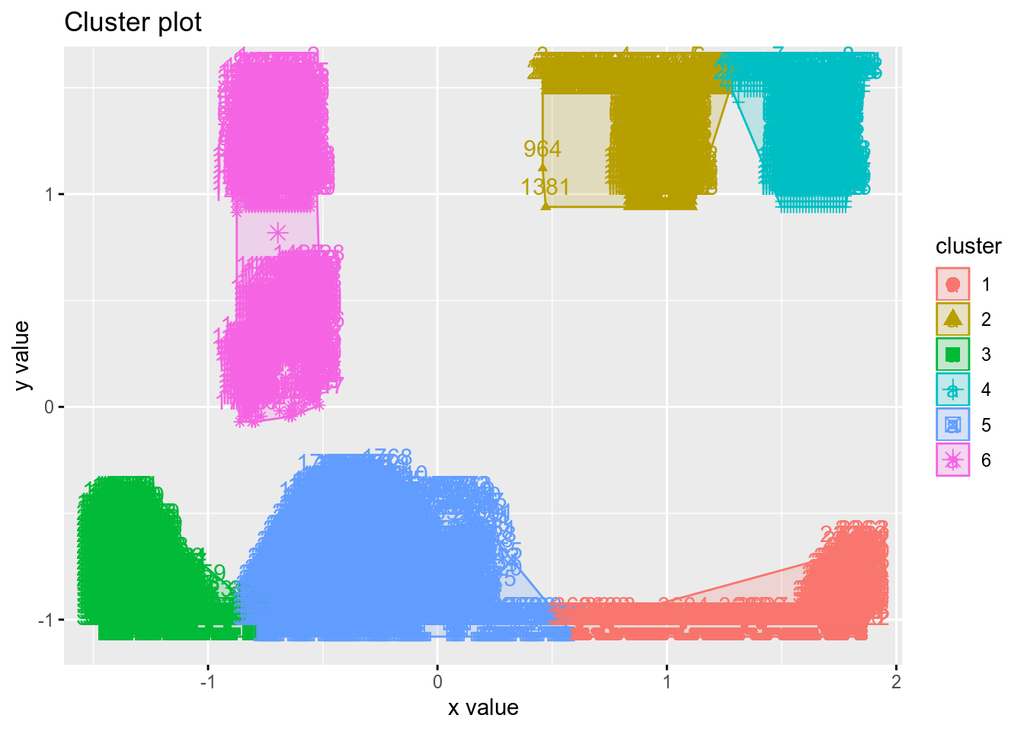

```r
k6_graph <- fviz_cluster(k6, clusterData)
k6_graph
```

### Cluster k=7

```r
k7 <- kmeans(clusterData, centers=7, nstart=25)
str(k7)
```

```
## List of 9
##  $ cluster     : int [1:4022] 7 7 2 2 2 2 1 1 7 7 ...
##  $ centers     : num [1:7, 1:2] 231.1 179.6 13.1 74.3 112.5 ...
##   ..- attr(*, "dimnames")=List of 2
##   .. ..$ : chr [1:7] "1" "2" "3" "4" ...
##   .. ..$ : chr [1:2] "x" "y"
##  $ totss       : num 28608985
##  $ withinss    : num [1:7] 65847 112959 75620 185247 177747 ...
##  $ tot.withinss: num 1102870
##  $ betweenss   : num 27506115
##  $ size        : int [1:7] 467 518 569 930 480 287 771
##  $ iter        : int 3
##  $ ifault      : int 0
##  - attr(*, "class")= chr "kmeans"
```

```r
k7
```

```
## K-means clustering with 7 clusters of sizes 467, 518, 569, 930, 480, 287, 771
##
## Cluster means:
##         x      y
## 1 231.090 224.37
## 2 179.550 225.27
## 3  13.072 143.25
## 4  74.288 145.84
## 5 112.542 142.31
## 6 227.084 137.95
## 7  57.315 207.76
##
## Clustering vector:
##    [1] 7 7 2 2 2 2 1 1 7 7 7 7 7 7 7 7 7 7 7 7 7 7 7 7 7 7 7 7 7 7 7 2 2 2
##   [35] 2 2 2 2 2 2 2 2 2 2 2 2 2 2 2 2 2 2 2 2 2 2 2 2 2 2 2 2 2 2 2 2 2 2
```

[output cut: 127 more lines]

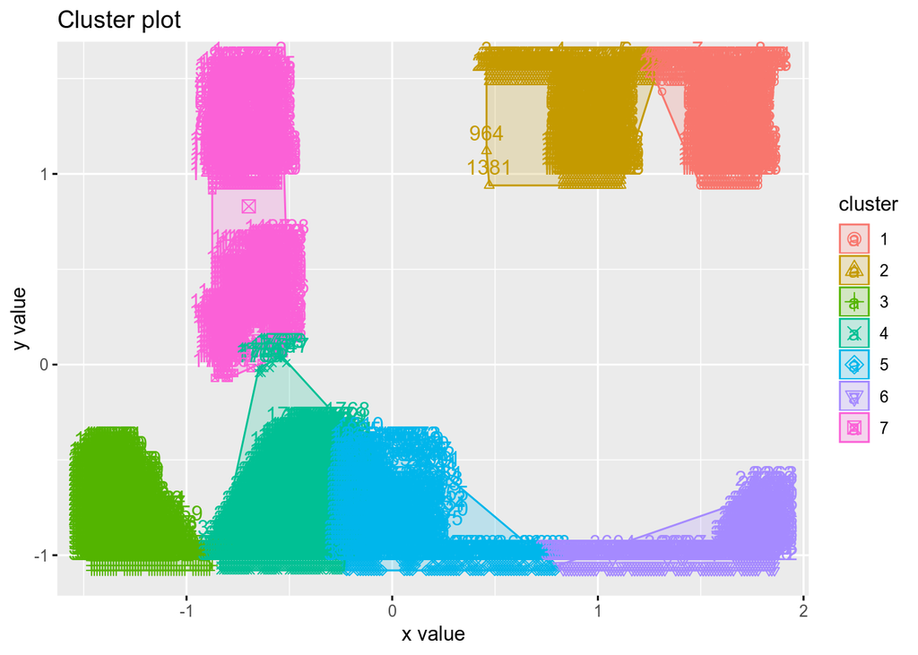

```r
k7_graph <- fviz_cluster(k7, clusterData)
k7_graph
```

### Cluster k=8

```r
k8 <- kmeans(clusterData, centers=8, nstart=25)
str(k8)
```

```
## List of 9
##  $ cluster     : int [1:4022] 5 5 7 7 7 7 1 1 5 5 ...
##  $ centers     : num [1:8, 1:2] 231.1 74.5 13.1 58.8 56.3 ...
##   ..- attr(*, "dimnames")=List of 2
##   .. ..$ : chr [1:8] "1" "2" "3" "4" ...
##   .. ..$ : chr [1:2] "x" "y"
##  $ totss       : num 28608985
##  $ withinss    : num [1:8] 65847 176363 75620 35775 47345 ...
##  $ tot.withinss: num 853160
##  $ betweenss   : num 27755825
##  $ size        : int [1:8] 467 924 569 341 441 475 518 287
##  $ iter        : int 3
##  $ ifault      : int 0
##  - attr(*, "class")= chr "kmeans"
```

```r
k8
```

```
## K-means clustering with 8 clusters of sizes 467, 924, 569, 341, 441, 475, 518, 287
##
## Cluster means:
##         x      y
## 1 231.090 224.37
## 2  74.499 145.46
## 3  13.072 143.25
## 4  58.827 186.98
## 5  56.345 223.02
## 6 112.743 142.30
## 7 179.550 225.27
## 8 227.084 137.95
##
## Clustering vector:
##    [1] 5 5 7 7 7 7 1 1 5 5 5 5 5 5 5 5 5 5 5 5 5 5 5 5 5 5 5 5 5 5 5 7 7 7
```

[output cut: 128 more lines]

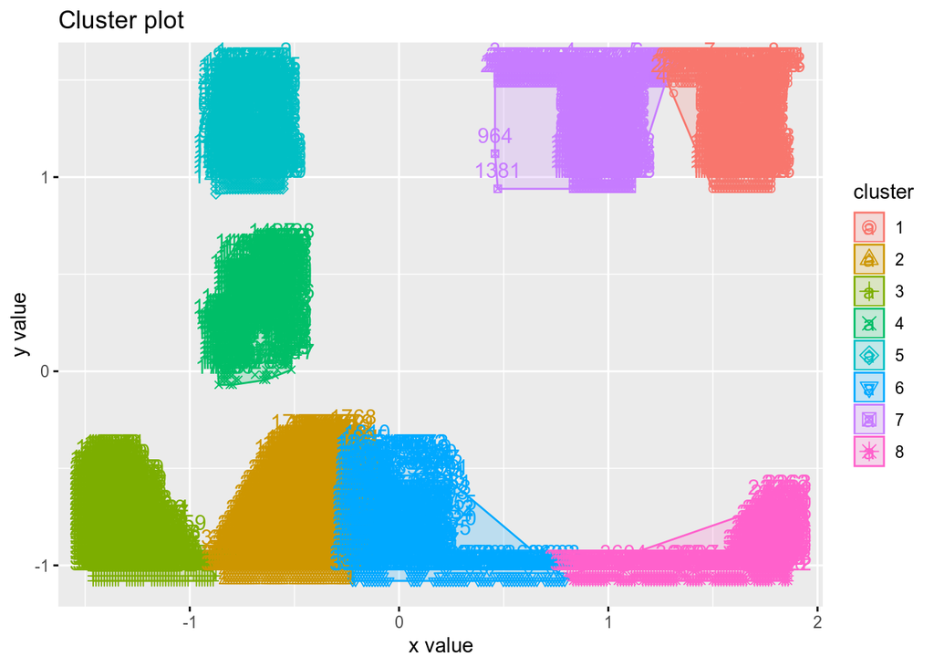

```r
k8_graph <- fviz_cluster(k8, clusterData)
k8_graph
```

### Cluster k=9

```r
k9 <- kmeans(clusterData, centers=9, nstart=25)
str(k9)
```

```
## List of 9
##  $ cluster     : int [1:4022] 9 9 7 7 7 7 4 4 9 9 ...
##  $ centers     : num [1:9, 1:2] 238.2 103.8 12.9 231.1 172.1 ...
##   ..- attr(*, "dimnames")=List of 2
##   .. ..$ : chr [1:9] "1" "2" "3" "4" ...
##   .. ..$ : chr [1:2] "x" "y"
##  $ totss       : num 28608985
##  $ withinss    : num [1:9] 30545 104094 72634 65847 45380 ...
##  $ tot.withinss: num 647329
##  $ betweenss   : num 27961656
##  $ size        : int [1:9] 224 548 566 467 116 341 518 801 441
##  $ iter        : int 4
##  $ ifault      : int 0
##  - attr(*, "class")= chr "kmeans"
```

```r
k9
```

```
## K-means clustering with 9 clusters of sizes 224, 548, 566, 467, 116, 341, 518, 801, 441
##
## Cluster means:
##         x      y
## 1 238.152 138.90
## 2 103.777 143.72
## 3  12.912 143.29
## 4 231.090 224.37
## 5 172.052 134.57
## 6  58.827 186.98
## 7 179.550 225.27
## 8  71.809 145.46
## 9  56.345 223.02
##
## Clustering vector:
```

[output cut: 129 more lines]

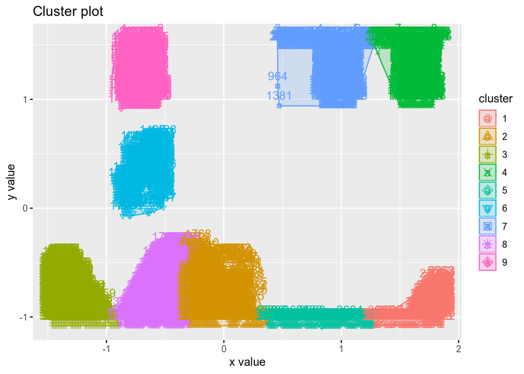

```r
k9_graph <- fviz_cluster(k9, clusterData)
k9_graph
```

### Cluster k10

```r
k10 <- kmeans(clusterData, centers=10, nstart=25)
str(k10)
```

```
## List of 9
##  $ cluster     : int [1:4022] 2 2 10 10 10 10 7 7 2 2 ...
##  $ centers     : num [1:10, 1:2] 239.3 56.3 118.6 179.4 89.4 ...
##   ..- attr(*, "dimnames")=List of 2
##   .. ..$ : chr [1:10] "1" "2" "3" "4" ...
##   .. ..$ : chr [1:2] "x" "y"
##  $ totss       : num 28608985
##  $ withinss    : num [1:10] 22577 47345 33365 34947 73371 ...
##  $ tot.withinss: num 554632
##  $ betweenss   : num 28054352
##  $ size        : int [1:10] 216 441 232 107 615 560 467 341 525 518
##  $ iter        : int 3
##  $ ifault      : int 0
##  - attr(*, "class")= chr "kmeans"
```

```r
k10
```

```
## K-means clustering with 10 clusters of sizes 216, 441, 232, 107, 615, 560, 467, 341, 525, 518
##
## Cluster means:
##          x      y
## 1  239.287 139.06
## 2   56.345 223.02
## 3  118.629 141.44
## 4  179.355 134.55
## 5   89.413 146.74
## 6   12.611 143.38
## 7  231.090 224.37
## 8   58.827 186.98
## 9   65.811 143.45
## 10 179.550 225.27
##
```

[output cut: 186 more lines]

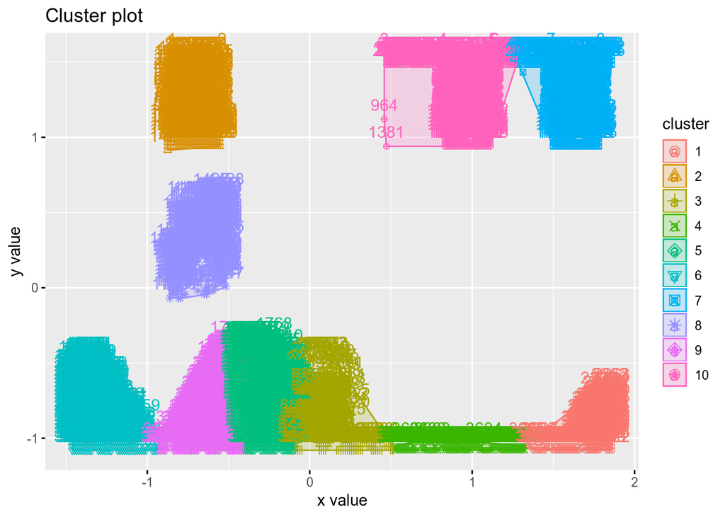

```r
k10_graph <- fviz_cluster(k10, clusterData)
k10_graph
```

### Cluster k=11

```r
k11 <- kmeans(clusterData, centers=11, nstart=25)
str(k11)
```

```
## List of 9
##  $ cluster     : int [1:4022] 10 10 4 4 3 3 5 5 10 10 ...
##  $ centers     : num [1:11, 1:2] 179.4 12.6 184 157.9 231.4 ...
##   ..- attr(*, "dimnames")=List of 2
##   .. ..$ : chr [1:11] "1" "2" "3" "4" ...
##   .. ..$ : chr [1:2] "x" "y"
##  $ totss       : num 28608985
##  $ withinss    : num [1:11] 34947 67392 55139 6716 62273 ...
##  $ tot.withinss: num 499954
##  $ betweenss   : num 28109030
##  $ size        : int [1:11] 107 560 439 84 462 232 341 615 525 441 ...
##  $ iter        : int 3
##  $ ifault      : int 0
##  - attr(*, "class")= chr "kmeans"
```

```r
k11
```

```
## K-means clustering with 11 clusters of sizes 107, 560, 439, 84, 462, 232, 341, 615, 525, 441, 216
##
## Cluster means:
##          x      y
## 1  179.355 134.55
## 2   12.611 143.38
## 3  184.007 223.77
## 4  157.857 233.63
## 5  231.357 224.26
## 6  118.629 141.44
## 7   58.827 186.98
## 8   89.413 146.74
## 9   65.811 143.45
## 10  56.345 223.02
## 11 239.287 139.06
```

[output cut: 188 more lines]

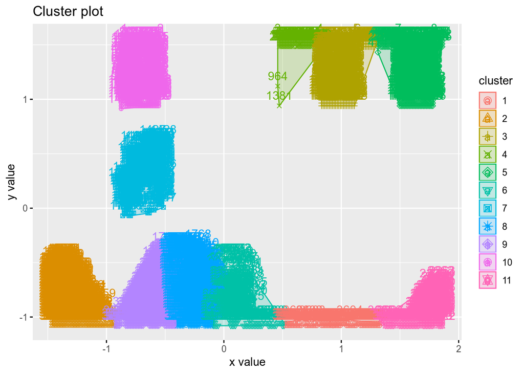

```r
k11_graph <- fviz_cluster(k11, clusterData)
k11_graph
```

### Cluster k=12

```r
k12 <- kmeans(clusterData, centers=12, nstart=25)
str(k12)
```

```
## List of 9
##  $ cluster     : int [1:4022] 4 4 8 8 5 5 9 9 4 4 ...
##  $ centers     : num [1:12, 1:2] 95 12.3 58.8 56.3 184 ...
##   ..- attr(*, "dimnames")=List of 2
##   .. ..$ : chr [1:12] "1" "2" "3" "4" ...
##   .. ..$ : chr [1:2] "x" "y"
##  $ totss       : num 28608985
##  $ withinss    : num [1:12] 31332 62365 35775 47345 55139 ...
##  $ tot.withinss: num 450061
##  $ betweenss   : num 28158924
##  $ size        : int [1:12] 402 553 341 441 439 305 215 84 462 104 ...
##  $ iter        : int 3
##  $ ifault      : int 0
##  - attr(*, "class")= chr "kmeans"
```

```r
k12
```

```
## K-means clustering with 12 clusters of sizes 402, 553, 341, 441, 439, 305, 215, 84, 462, 104, 467, 209
##
## Cluster means:
##          x      y
## 1   95.025 143.85
## 2   12.293 143.50
## 3   58.827 186.98
## 4   56.345 223.02
## 5  184.007 223.77
## 6   60.052 139.91
## 7  239.423 139.08
## 8  157.857 233.63
## 9  231.357 224.26
## 10 180.798 134.57
## 11  77.355 149.46
```

[output cut: 189 more lines]

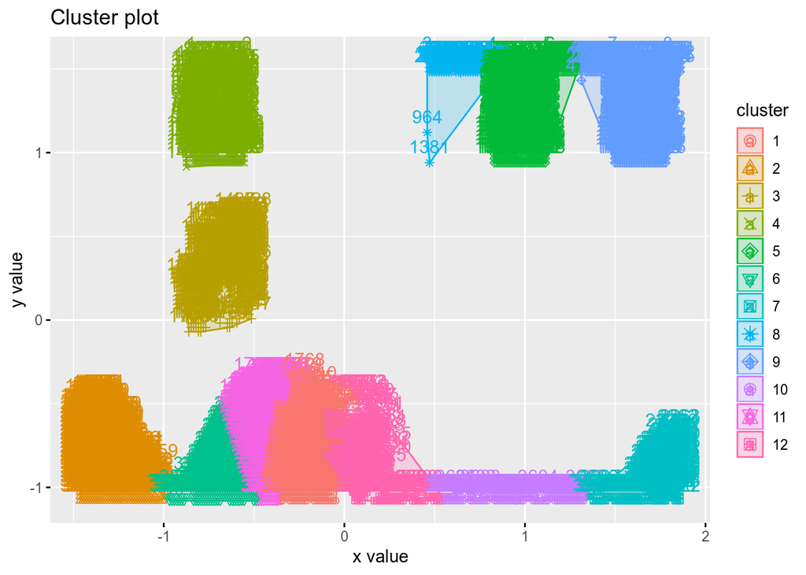

```r
k12_graph <- fviz_cluster(k12, clusterData)
k12_graph
```

##Calculate this average distance from the center of each cluster for each value of k and plot it as a line chart where k is the x-axis and the average distance is the y-axis.

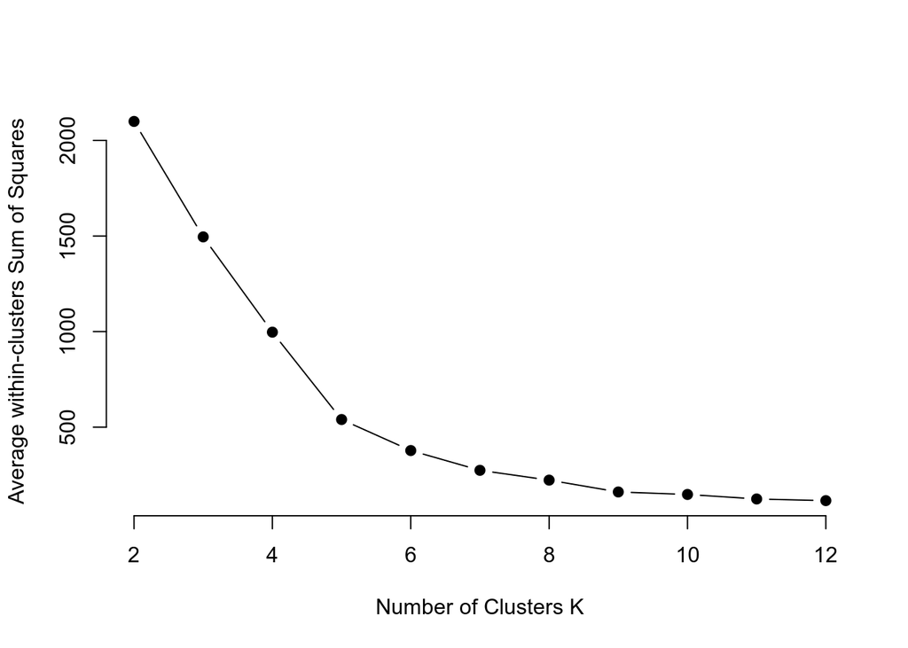

```r
# create function to compute average within-cluster sum of squares
withinSumSq <- function(k) {kmeans(clusterData, k, nstart=10)$tot.withinss/4022}

#set the values of k, from 2-12
kValues <- 2:12

#compute the within Sum of Squares for 2-12 clusters
withinSSValues <- map_dbl(kValues, withinSumSq)

#plot the line chart of k-value versus Sum of Squares
plot(kValues, withinSSValues, type="b", pch=19, frame=FALSE,
     xlab="Number of Clusters K", ylab="Average within-clusters Sum of Squares")
```

##One way of determining the “right” number of clusters is to look at the graph of k versus average distance and finding the “elbow point”. Looking at the graph you generated in the previous example, what is the elbow point for this dataset?

The elbow point appears to be k=5, based on the graph.